# Lesson 3

# Read in data

```r
#use sep to indicate file is tab seperated
pf <- read.csv('pseudo_facebook.tsv', sep = '\t')
names(pf)
```

```
##  [1] "userid"                "age"
##  [3] "dob_day"               "dob_year"
##  [5] "dob_month"             "gender"
##  [7] "tenure"                "friend_count"
##  [9] "friendships_initiated" "likes"
## [11] "likes_received"        "mobile_likes"
## [13] "mobile_likes_received" "www_likes"
## [15] "www_likes_received"
```

### Histogram of Users’ Birthdays

Notes:

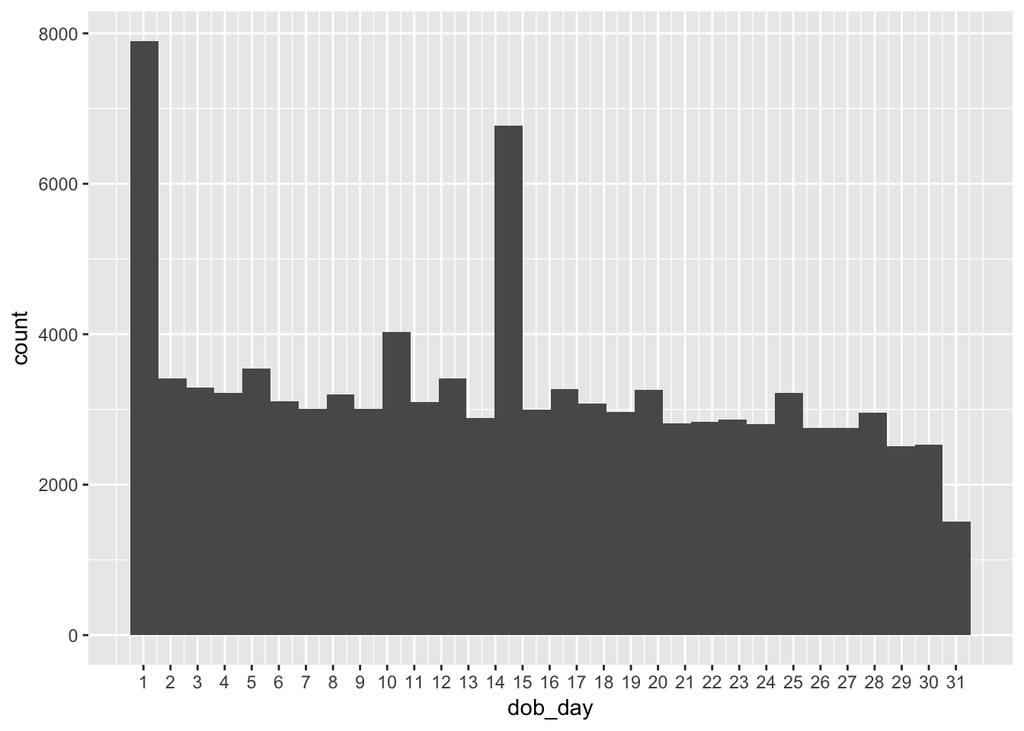

```r
#install.packages('ggplot2')
library(ggplot2)

qplot(x=dob_day, data=pf) +
  scale_x_continuous(breaks = 1:31)
```

#### What are some things that you notice about this histogram?

Response: # A large spike on the first day. This is the default so a lot of people probably didnt bother changing to correct date. The dip on the 31st is to be expected as not all months have 31 days in them

### Faceting

Notes:

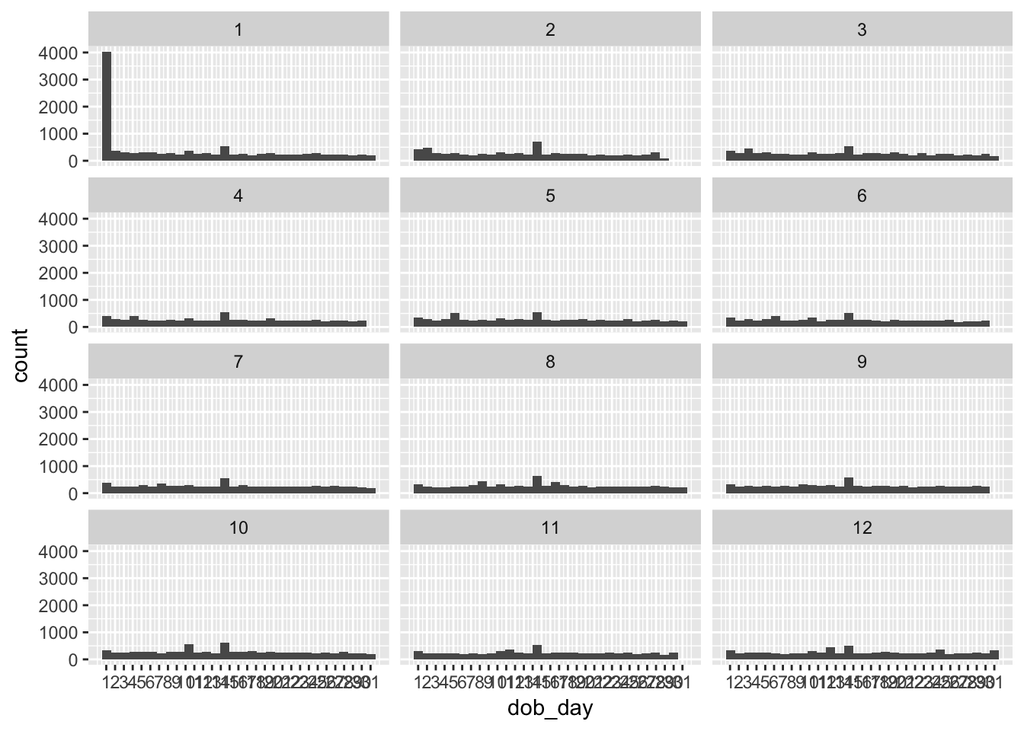

```r
# Get a plot for each of the 12 months. ncol specifies having 3 columns of histograms
qplot(x=dob_day, data = pf) +
  scale_x_continuous(breaks = 1:31) +
  facet_wrap(~dob_month, ncol =3)
```

#### Let’s take another look at our plot. What stands out to you here?

Response: # The spike for the first date of a month only happens in January. Calendar must be preset to Jan 1st and people arent bothered changing it

#### What code would you enter to create a histogram of friend counts?

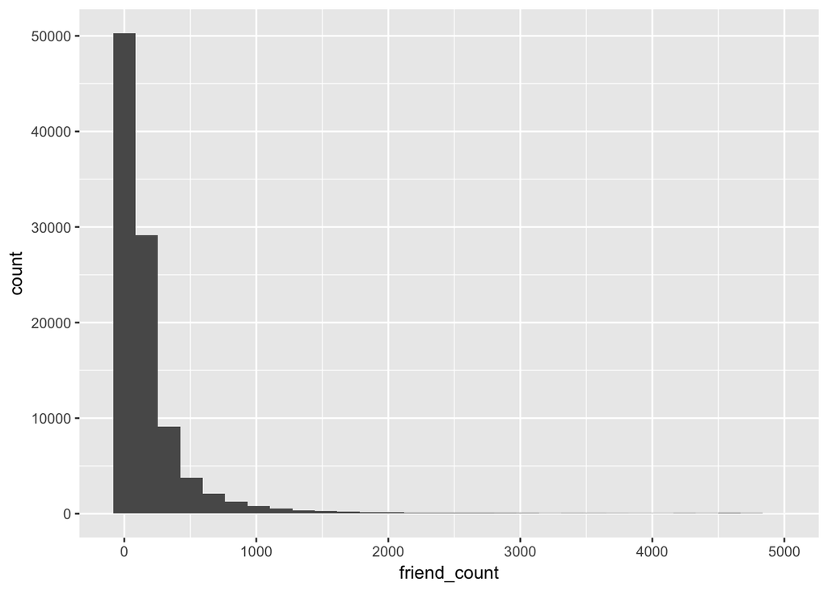

```r
qplot(x=friend_count, data=pf)
```

### Limiting the Axes

Notes: The bulk of out data is below the 1000 friends point so we’ll focus on that using xlim or use: + scale_x_continuous(limits = c(0, 1000))

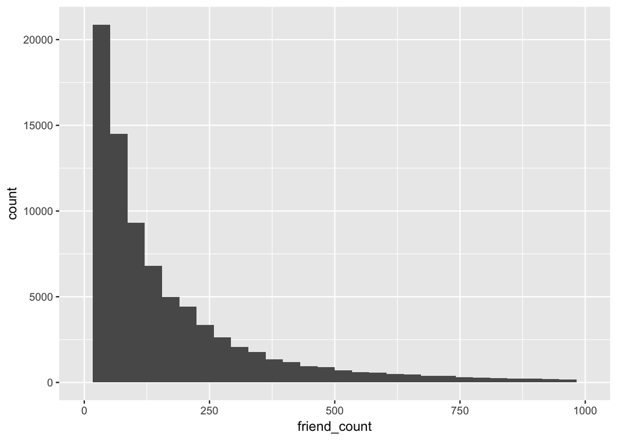

```r
qplot(x=friend_count, data=pf, xlim = c(0,1000))
```

### Adjusting the Bin Width

Notes: breaks = seq(0, 1000, 50) says go from 0 to 1000 in steps of 50

### Faceting Friend Count

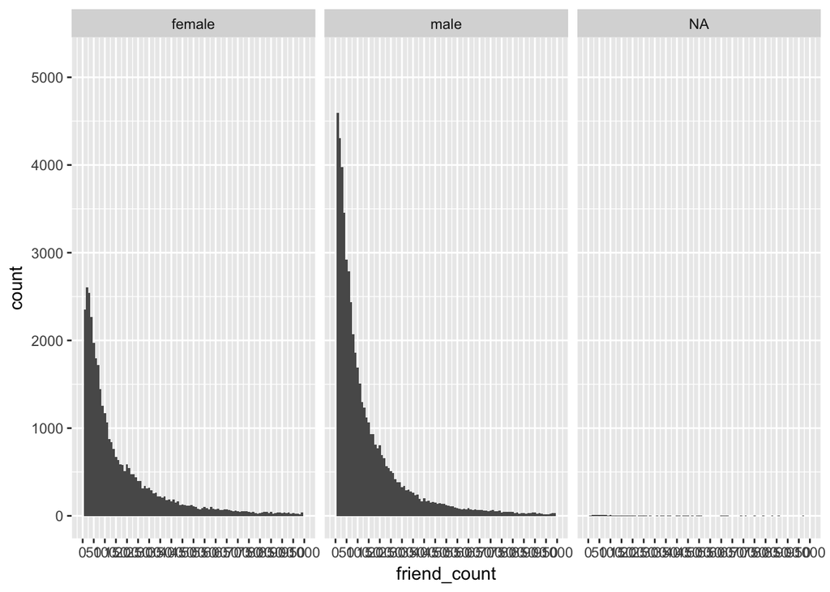

```r
# create a facet the histogram by gender?
qplot(x = friend_count, data = pf, binwidth = 10) +
  scale_x_continuous(limits = c(0, 1000),
                     breaks = seq(0, 1000, 50)) +
  facet_wrap(~gender)
```

### Omitting NA Values

Notes: could use data=na.omit(pf) but this will omit any rows that have na for any of their values and not just gender

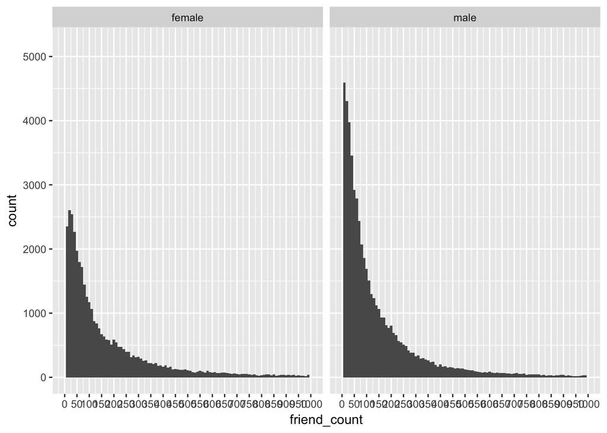

```r
qplot(x = friend_count, data = subset(pf, !is.na(gender)), binwidth = 10) +
  scale_x_continuous(limits = c(0, 1000),
                     breaks = seq(0, 1000, 50)) +
  facet_wrap(~gender)
```

### Statistics ‘by’ Gender

Notes:

```r
table(pf$gender)
```

```
##
## female   male
##  40254  58574
```

```r
by(pf$friend_count, pf$gender, summary)
```

```
## pf$gender: female
##    Min. 1st Qu.  Median    Mean 3rd Qu.    Max.
##       0      37      96     242     244    4923
## --------------------------------------------------------
## pf$gender: male
##    Min. 1st Qu.  Median    Mean 3rd Qu.    Max.
##       0      27      74     165     182    4917
```

#### Why would the median be a better measure than the mean?

Response: Median is a more robust statistic. A few people with huge friend counts drag the mean upwards which isnt representative of most users. Median is not affected by these extreme values

### Tenure

Notes:

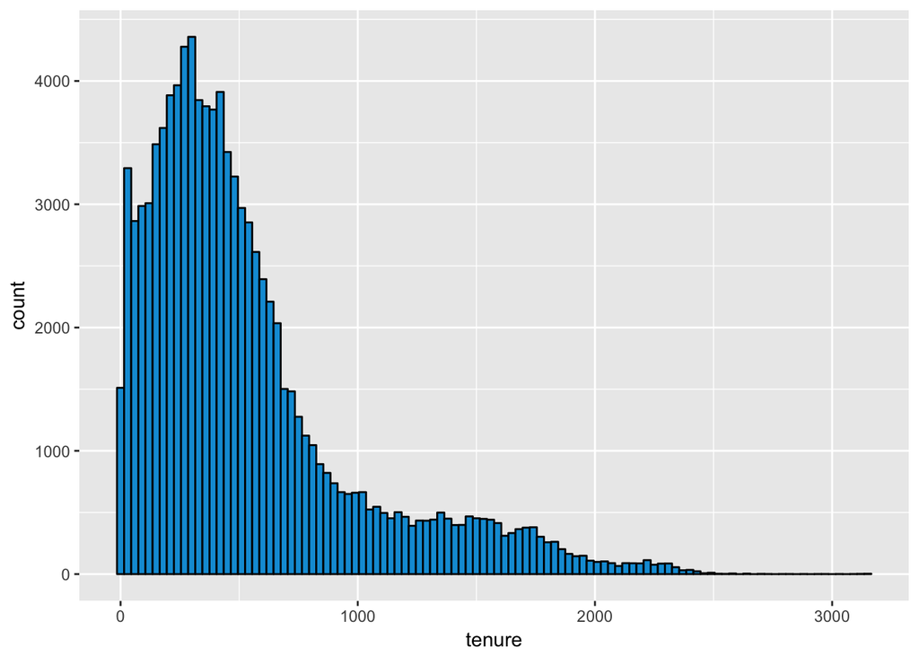

```r
qplot(x=tenure, data = pf, binwidth=30,
      color=I('black'), fill=I('#099DD9'))
```

#### How would you create a histogram of tenure by year?

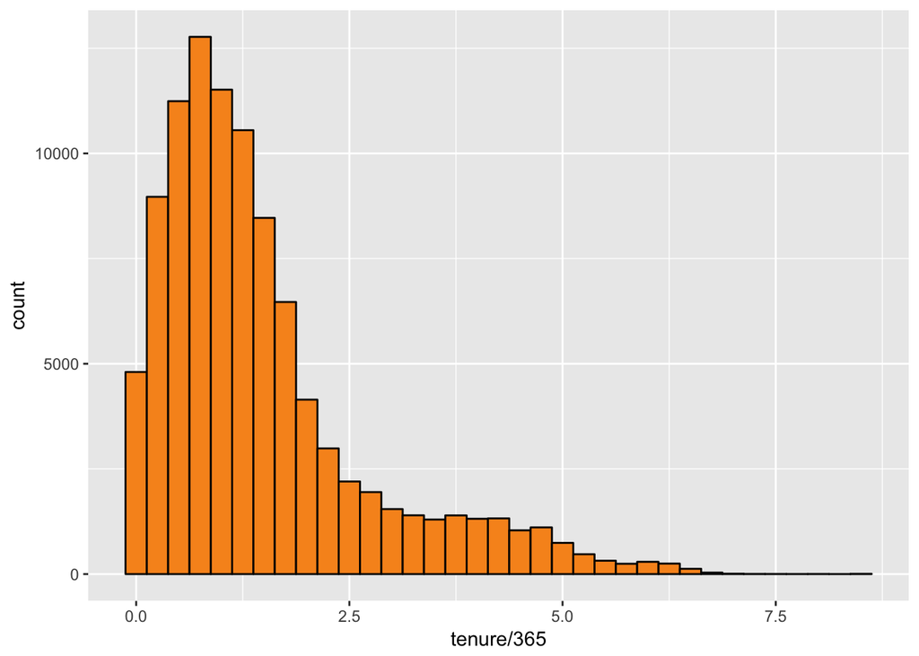

```r
qplot(x=tenure/365, data = pf, binwidth=0.25,
      color=I('black'), fill=I('#F79420')  )
```

### Labeling Plots

Notes:

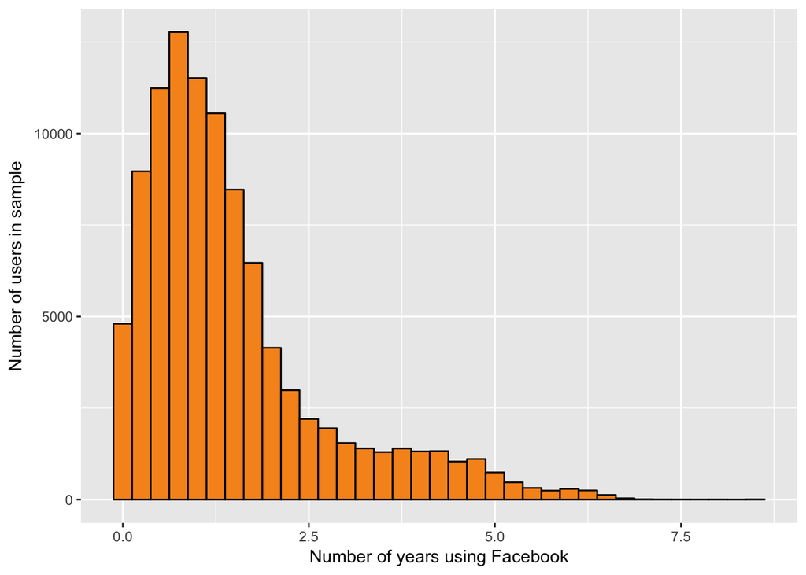

```r
qplot(x=tenure/365, data = pf, binwidth=0.25,
      xlab ='Number of years using Facebook',
      ylab='Number of users in sample',
      color=I('black'), fill=I('#F79420') )
```

### User Ages

Notes: Running summary(pf$age) will give min and max ages seq(0,113,5) goes from 0 to 113 in units of 5

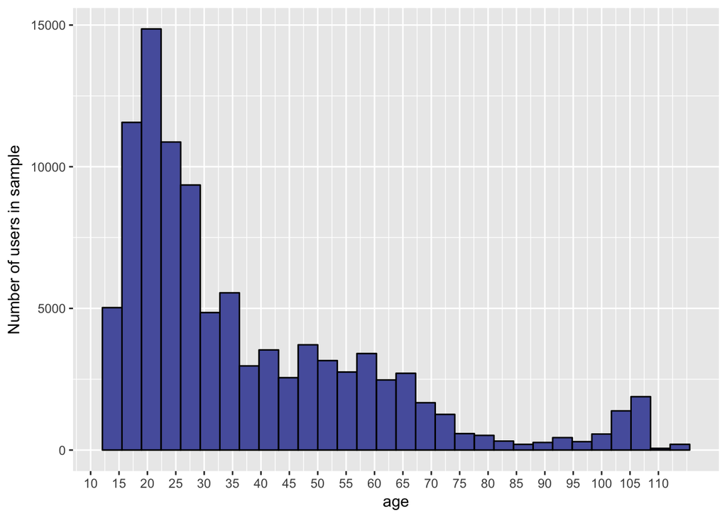

```r
qplot(x=age, data=pf, bunwidth=1, xlab = "age",
      ylab='Number of users in sample',
      color=I('black'), fill=I('#5760AB')) +
      scale_x_continuous(breaks = seq(0,113,5))
```

### Transforming Data

Notes:

```r
#qplot(x=friend_count, data =pf)
summary(pf$friend_count)
```

```
##    Min. 1st Qu.  Median    Mean 3rd Qu.    Max.
##     0.0    31.0    82.0   196.4   206.0  4923.0
```

```r
#getting log10 of 0 is undefined so the min - where people have 0 friends
#would yield a result of negative infinity. In order to avoid this we add # 1 to the friend count
summary(log10(pf$friend_count +1))
```

```
##    Min. 1st Qu.  Median    Mean 3rd Qu.    Max.
##   0.000   1.505   1.919   1.868   2.316   3.692
```

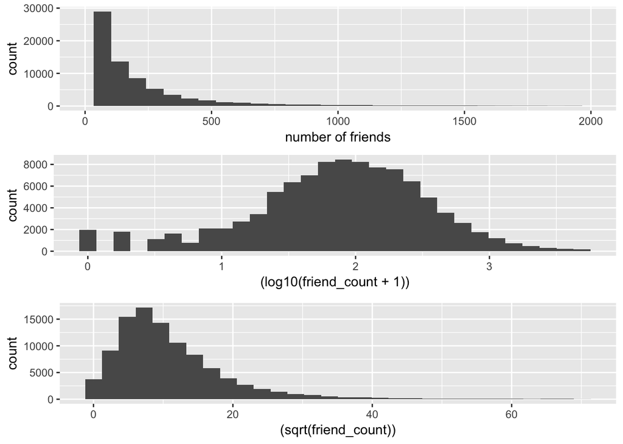

```r
#install.packages('gridExtra')
library(gridExtra)

# define individual plots
p1 <- qplot( x=friend_count, data = pf) + labs(x = 'number of friends', y = 'count') + xlim(0,2000)
p2 <- qplot( x=(log10(friend_count +1)), data = pf)
p3 <- qplot( x=(sqrt(friend_count)), data = pf)

# arrange plots in grid
grid.arrange(p1, p2, p3, ncol=1)
```

### Add a Scaling Layer

Notes:

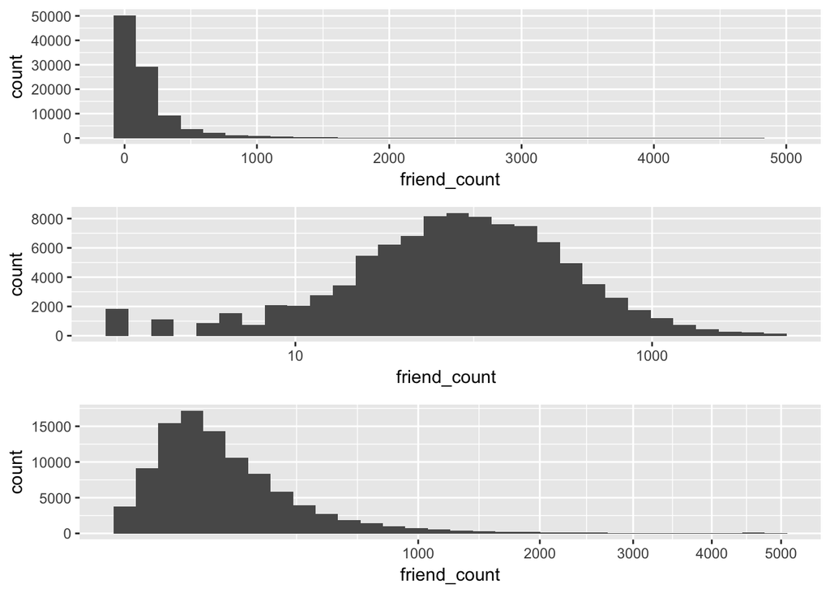

```r
#Alternative method for above
p1 <- ggplot(aes(x=friend_count), data=pf) + geom_histogram()
p2<- p1 + scale_x_log10()
p3<- p1 + scale_x_sqrt()

# arrange plots in grid
grid.arrange(p1, p2, p3, ncol=1)
```

```r
#Keep in mind this method has the same label for the x axis in all plots but it would be more helpful to know when log10 or sqrt was used in the labels
```

### Frequency Polygons

Comparing male and female friend counts in an overlay with a *frequency polygon* rather than two histograms side by side. Set color = gender so we get two different coloured lines for each of the genders. Change y axis to show prportions instead of counts: y = ..count../sum(..count..)

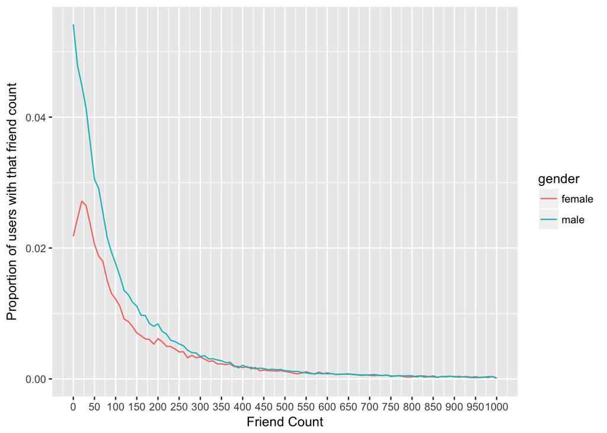

```r
ggplot(aes(x = friend_count, y = ..count../sum(..count..)),
       data = subset(pf, !is.na(gender))) +
  geom_freqpoly(aes(color = gender), binwidth=10) +
  scale_x_continuous(limits = c(0, 1000), breaks = seq(0, 1000, 50)) +
  xlab('Friend Count') +
  ylab('Proportion of users with that friend count')
```

### Likes on the Web

Notes:

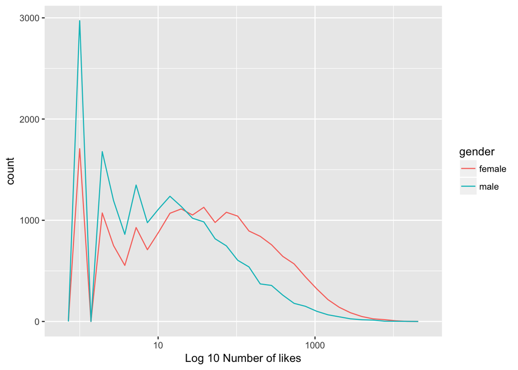

```r
ggplot(aes(x = www_likes), data = subset(pf, !is.na(gender))) +
  geom_freqpoly(aes(color=gender)) +
  scale_x_log10() +
  xlab("Log 10 Number of likes")
```

```r
#What's the www_like count for males?
#Which gender has more likes?

#Want to spli the like by gender and perform the sum function:
by(pf$www_likes, pf$gender, sum)
```

```
## pf$gender: female
## [1] 3507665
## --------------------------------------------------------
## pf$gender: male
## [1] 1430175
```

### Box Plots

Notes: With boxplots the continuous variable will be displayed on the y axis and the grouping/categorical variable will be on the x axis

- The boxes cover the middle 50% of values or what’s called the IQR
- The dots represent the outliers - there a re a lot present in this graph
- Outliers are points that lie outside of 1.5 times the IQR from the median
- The horizontal line inside the boxes is the median

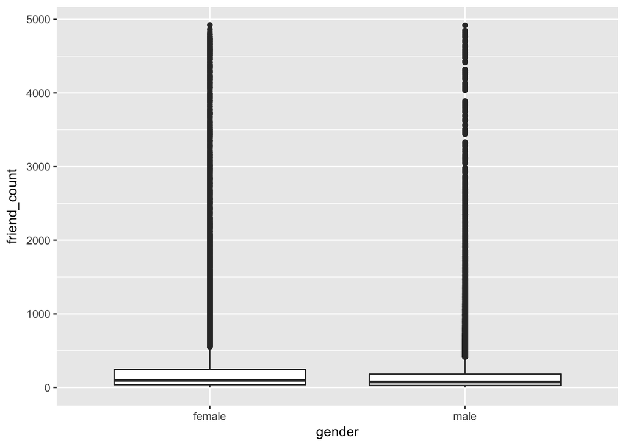

```r
ggplot(aes(x = gender, y=friend_count),
       data = subset(pf, !is.na(gender))) +
  geom_boxplot()
```

#### Adjust the code to focus on users who have friend counts between 0 and 1000.

- When you use the *ylim* or *scale_y_continuous* paramater you’re actually removing points from the calculations.
- A better way to do this is to use *coord_cartesian*

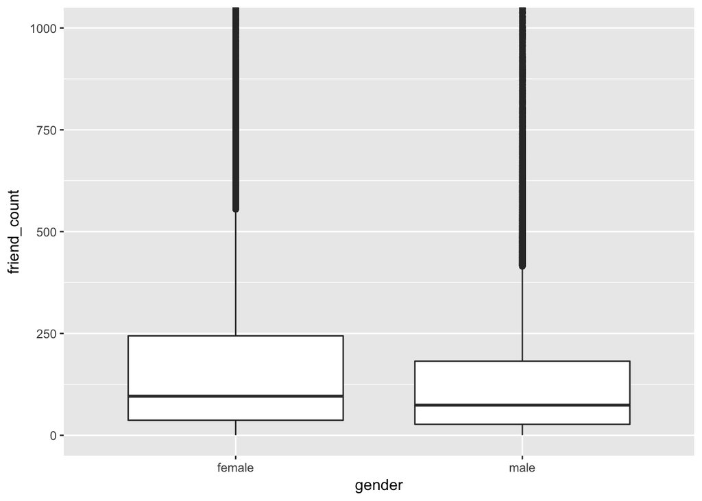

```r
ggplot(aes(x = gender, y=friend_count),
       data = subset(pf, !is.na(gender))) +
  geom_boxplot() +
  coord_cartesian(ylim=c(0,1000))
```

### Box Plots, Quartiles, and Friendships

Notes:

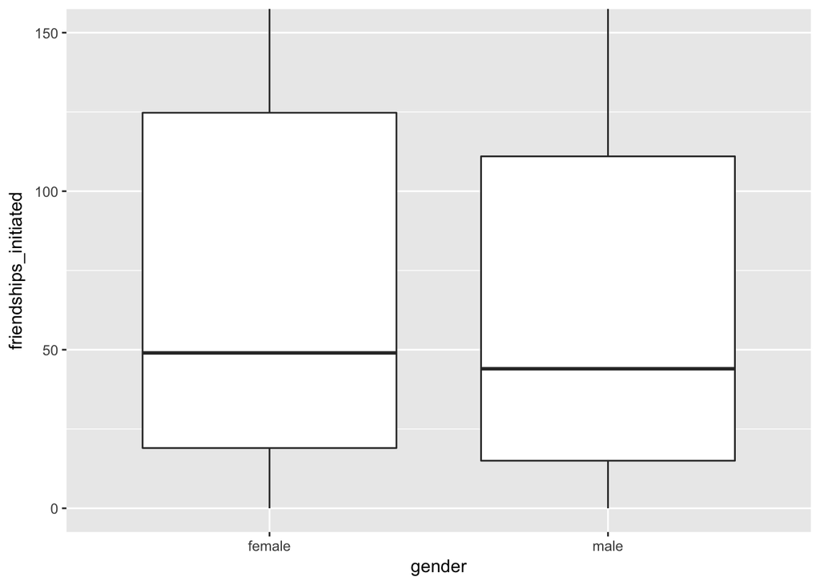

```r
ggplot(aes(x = gender, y=friendships_initiated),
       data = subset(pf, !is.na(gender))) +
  geom_boxplot() +
  coord_cartesian(ylim=c(0,150))
```

```r
by(pf$friendships_initiated, pf$gender, summary)
```

```
## pf$gender: female
##    Min. 1st Qu.  Median    Mean 3rd Qu.    Max.
##     0.0    19.0    49.0   113.9   124.8  3654.0
## --------------------------------------------------------
## pf$gender: male
##    Min. 1st Qu.  Median    Mean 3rd Qu.    Max.
##     0.0    15.0    44.0   103.1   111.0  4144.0
```

### Getting Logical

Notes:

```r
summary(pf$mobile_likes)
```

```
##    Min. 1st Qu.  Median    Mean 3rd Qu.    Max.
##     0.0     0.0     4.0   106.1    46.0 25111.0
```

```r
#See if someone has actually checked in on a mobile device rather than the number of times:
summary(pf$mobile_likes>0)
```

```
##    Mode   FALSE    TRUE
## logical   35056   63947
```

```r
#create our own variable to track whather a user had logged in on mbile
mobile_check_in <- NA
#Assign value of 1 if user has checked in on mobile and 0 otherwise:
pf$mobile_check_in <- ifelse(pf$mobile_likes>0, 1, 0)
#convert to factor variable
pf$mobile_check_in <- factor(pf$mobile_check_in)
summary(pf$mobile_check_in)
```

```
##     0     1
## 35056 63947
```

```r
#Find % of users signed in on mobile:
percent_mobile_check_in = sum(pf$mobile_check_in==1)/length(pf$mobile_check_in)
percent_mobile_check_in
```

```
## [1] 0.6459097
```

```r
#install.packages('knitr', dependencies = T)
library(knitr)
setwd("/Users/Sian/Intro_data_analysis/EDA/Lesson 3")
```

Click **KnitHTML** to see all of your hard work and to have an html page of this lesson, your answers, and your notes!